# IODS course project

Jussi Järvinen

# 1 About the project

This is nice. I look forward to improving my R skills and learning some good open data practices.

**What I expect to learn?**

- Open data practices
- Practice R
- R Markdown (this is my first time using)
- Recap some data science analyses and good scientific practices

**Where I learned about the course?**

I think I just brosed the HYMY courses in WebOodi.

**Link to my repository: https://github.com/jarvinenjussi/IODS-project**

# 2 Regression and Model Validation

## Overview of the Data

```r
data <- read.csv("data/learning2014.csv", row.names = 1)
```

The data is from Kimmo Vehkalahti’ study ASSIST 2014, which measured the approaches to learning of 183 university students in the Introduction to Social Statistics course in Fall 2014.

```r
dim(data)
```

```
## [1] 166   7
```

```r
str(data)
```

```
## 'data.frame':    166 obs. of  7 variables:
##  $ gender  : Factor w/ 2 levels "F","M": 1 2 1 2 2 1 2 1 2 1 ...
##  $ age     : int  53 55 49 53 49 38 50 37 37 42 ...
##  $ attitude: int  37 31 25 35 37 38 35 29 38 21 ...
##  $ deep    : num  3.58 2.92 3.5 3.5 3.67 ...
##  $ stra    : num  3.38 2.75 3.62 3.12 3.62 ...
##  $ surf    : num  2.58 3.17 2.25 2.25 2.83 ...
##  $ points  : int  25 12 24 10 22 21 21 31 24 26 ...
```

The data has 7 variables:

- *Gender*: M (Male), F (Female)
- *Age* (in years) derived from the date of birth
- *Global attitude toward statistics*
- *Deep learning* measured with 12 items
- *Strategic learning* measured with 8 items
- *Surface learning* measured with 12 items
- *Exam points*

Composite variables assessing the approaches to learning were formed combining items measuring each construct by calculating the item means for each participant. 166 cases were included in the analyses as 17 cases with the score 0 for exam points were omitted.

```r
library(GGally)
library(ggplot2)
library(dplyr)
library(psych)
library(ggpubr)
```

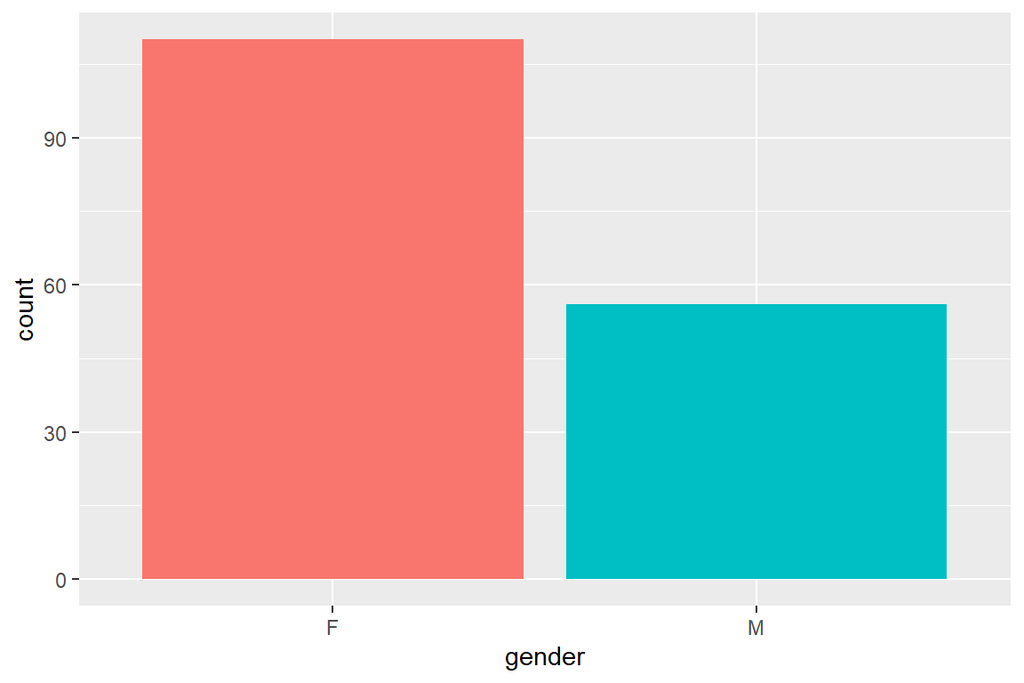

```r
p1 <- ggplot(data, aes(x=gender, fill = gender)) + geom_bar()
p1 + theme(legend.position = "none")
```

```r
data %>% count(gender)
```

```
## # A tibble: 2 x 2
##   gender     n
##   <fct>  <int>
## 1 F        110
## 2 M         56
```

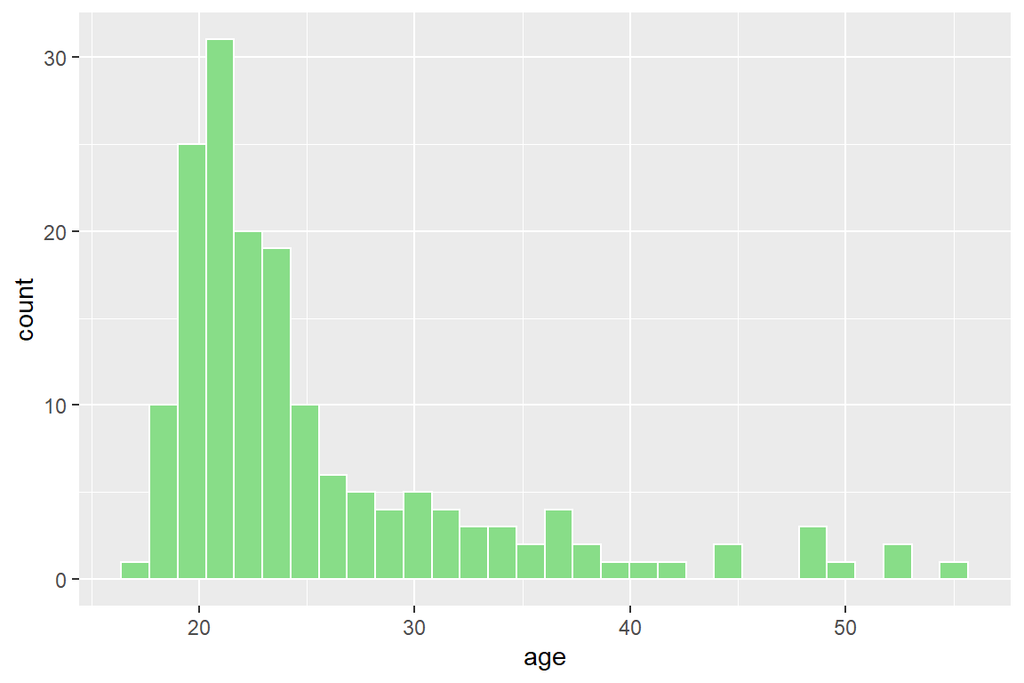

```r
ggplot(data, aes(age)) + geom_histogram(color="white", fill="#88dd88")
```

```r
mean(data$age)
```

```
## [1] 25.51205
```

```r
range(data$age)
```

```
## [1] 17 55
```

There are 110 females and 56 males in the dataset and the ages of the participants range from 17 to 55 years with the average age being 25.5.

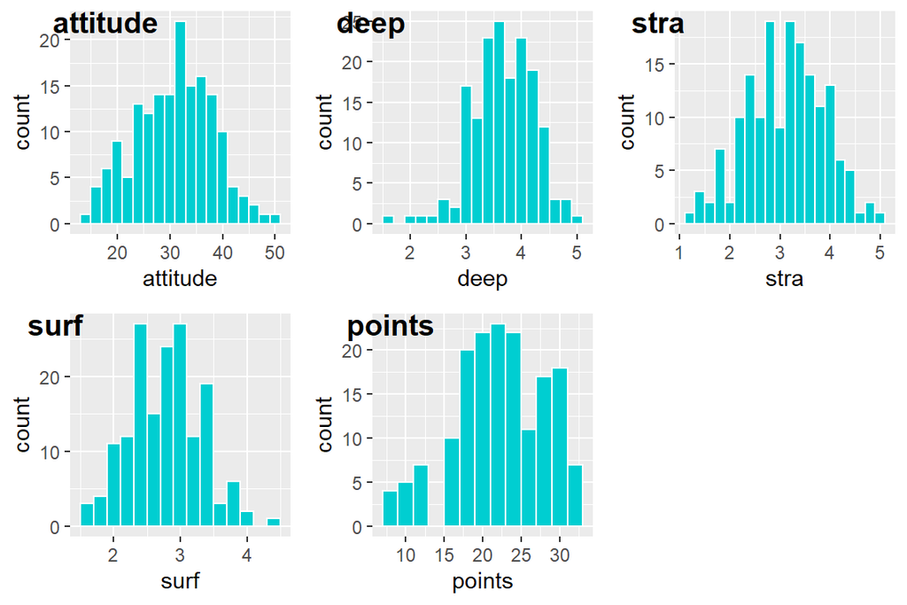

```r
p2 <- ggplot(data, aes(attitude)) + geom_histogram(color="white", fill="darkturquoise", binwidth = 2)
p3 <- ggplot(data, aes(deep)) + geom_histogram(color="white", fill="darkturquoise", binwidth = 0.2)
p4 <- ggplot(data, aes(stra)) + geom_histogram(color="white", fill="darkturquoise", binwidth = 0.2)
p5 <- ggplot(data, aes(surf)) + geom_histogram(color="white", fill="darkturquoise", binwidth = 0.2)
p6 <- ggplot(data, aes(points),) + geom_histogram(color="white", fill="darkturquoise", binwidth = 2)

figure <- ggarrange(p2, p3, p4, p5, p6,
                    labels = c("attitude", "deep", "stra", "surf", "points"),
                    ncol = 3, nrow = 2)
figure
```

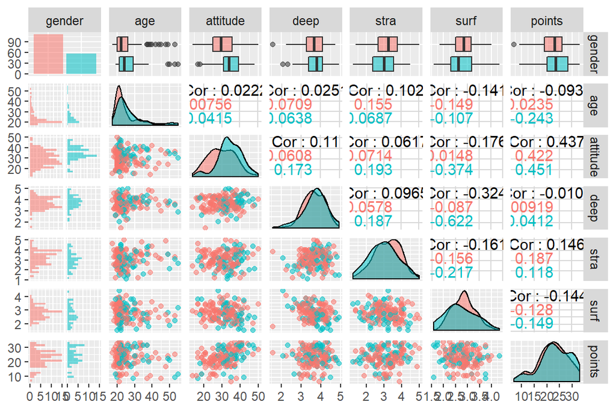

```r
p7 <- ggpairs(data, mapping = aes(col=gender, alpha=0.3), lower = list(combo = wrap("facethist", bins = 20)))
p7
```

```r
describe(data[,-1])
```

```
##          vars   n  mean   sd median trimmed  mad   min   max range  skew
## age         1 166 25.51 7.77  22.00   23.99 2.97 17.00 55.00 38.00  1.89
## attitude    2 166 31.43 7.30  32.00   31.52 7.41 14.00 50.00 36.00 -0.08
## deep        3 166  3.68 0.55   3.67    3.70 0.62  1.58  4.92  3.33 -0.50
## stra        4 166  3.12 0.77   3.19    3.14 0.83  1.25  5.00  3.75 -0.11
## surf        5 166  2.79 0.53   2.83    2.78 0.62  1.58  4.33  2.75  0.14
## points      6 166 22.72 5.89  23.00   23.08 5.93  7.00 33.00 26.00 -0.40
##          kurtosis   se
## age          3.24 0.60
## attitude    -0.48 0.57
## deep         0.66 0.04
## stra        -0.45 0.06
## surf        -0.27 0.04
## points      -0.26 0.46
```

Other variables seem to be quite symmetrically distributed with a slight negative skewness on deep learning and exam points. By visual inspection, it seems there might be a gender difference in attitude towards statistics with men having more positive attitude in average.

Attitude and exam points are moderately correlated. There is also a weak positive and a weak negative correlation between exam points and strategic learning, and exam points and surface learning, respectively. Intrestingly, deep learning is not correlated with exam points. Surface learning is also negatively correlated to deep and surface learning as well as attitude (r = -.32 … -.16).

## Regression models

### Model 1

```r
mod1 <- lm(points ~ attitude + stra + surf, data = data)
summary(mod1)
```

```
##
## Call:
## lm(formula = points ~ attitude + stra + surf, data = data)
##
## Residuals:
##      Min       1Q   Median       3Q      Max
## -17.1550  -3.4346   0.5156   3.6401  10.8952
##
## Coefficients:
##             Estimate Std. Error t value Pr(>|t|)
## (Intercept) 11.01711    3.68375   2.991  0.00322 **
## attitude     0.33952    0.05741   5.913 1.93e-08 ***
## stra         0.85313    0.54159   1.575  0.11716
## surf        -0.58607    0.80138  -0.731  0.46563
## ---
## Signif. codes:  0 '***' 0.001 '**' 0.01 '*' 0.05 '.' 0.1 ' ' 1
##
## Residual standard error: 5.296 on 162 degrees of freedom
## Multiple R-squared:  0.2074, Adjusted R-squared:  0.1927
## F-statistic: 14.13 on 3 and 162 DF,  p-value: 3.156e-08
```

I chose attitude, strategic learning and surgace learning as predictors in my regression model based on the strenght of correlation on exam points.

The **F-statistic** gives a test of the omnibus null hypothesis that all regression coefficients are zero. The F-statistic for the Model 1 is 14.13 with a *p* value less than .001. Following, it is highly unlikely that there are no non-zero regressions in the model and we can reject the null hypothesis.

The **square of the multiple correlation coefficient (R^2)** is .207, which signifies that the variables in the model account for about 21% of the variation in exam points.

However, the non-significant *t*-value of strategic and surface learning implies that attitude seems to be the only statistically significant predictor in the model (*t* = 5.91, *p* < .001). The *t* test tests whether the regression coefficient differs from zero.

The unstandardized **regression coefficients** are reported under “Estimate” in the “Coefficients” table. The coefficient .34 (*p* < .001) of attitude implies the strength of the relationship between attitude and exam points in the original scales of the variables, when strategic and surface learning is controlled for. However, we cannot make judgements about the relative importance of the predictor on the predicted variable using unstandardized coefficients. We can obtain the standardized values by multiplying the raw regression coefficient by multiplying the raw coefficient by the standard deviation of the explanatory variable and dividing by the standard deviation of the response variable:

[output not shown]

From the “Residuals” table, we can also see how the model **residuals** are distributed.